# CaseStudy3 - GPA Prediction using Linear Regression

2024-11-16

### Summary

Data: Student GPA data was downloaded from Kaggle with GPA as dependent variable from 2,392 students with multiple independent variables such as Absences, StudyTimeWeekly, Tutoring, ParentalSupport, ParentalEducation, Age, Gender, Ethnicity

Motivation: The goal of this project is to create a linear regression model that will to predict the GPA of a student given multiple independent variables as inputs. This is interesting as it will serve as a motivation and visualition tool for many students who are struggling with the concept of studying. The output of this project will show what factors contribute to academic success and by how much.

The analysis of the data: Visreg package was used to initially filter out variables that do not factor to reduce complexity of the UI and 5 top factors. Afterwards, linear regression model was used to predict the GPA based on the input variables.

Metrics for the model: Based on the results below, the model generated with Absences, StudyTimeWeekly, Tutoring, ParentalSupport, Age showed Coefficient of determination (R2) value of .93 and root mean squared error of prediction (RMSEP) of .24 indicating we do have a good linear regression model for GPA prediction.

GITHUB REPO: https://github.com/HyeonsuKim000/CaseStudy3

Shiny App: https://hyeonsukim-wpi-ds501.shinyapps.io/casestudy3/

### Loading packages that we will be using

```r
library(dplyr)
library(plsdepot)
library(ggplot2)
library(visreg)
library(caret)
```

### Using Data from https://www.kaggle.com/code/joelknapp/student-performance-analysis

Observed data size, variable types, ranges, etc.

```r
studentData = read.csv("Data/Student_GPA_Data.csv")
head(studentData)
```

```
##   StudentID Age Gender Ethnicity ParentalEducation StudyTimeWeekly Absences
## 1      1001  17      1         0                 2       19.833723        7
## 2      1002  18      0         0                 1       15.408756        0
## 3      1003  15      0         2                 3        4.210570       26
## 4      1004  17      1         0                 3       10.028829       14
## 5      1005  17      1         0                 2        4.672495       17
## 6      1006  18      0         0                 1        8.191219        0
##   Tutoring ParentalSupport Extracurricular Sports Music Volunteering       GPA
## 1        1               2               0      0     1            0 2.9291956
## 2        0               1               0      0     0            0 3.0429148
## 3        0               2               0      0     0            0 0.1126023
## 4        0               3               1      0     0            0 2.0542181
## 5        1               3               0      0     0            0 1.2880612
## 6        0               1               1      0     0            0 3.0841836
##   GradeClass
## 1          2
## 2          1
## 3          4
## 4          3
## 5          4
## 6          1
```

```r
summary(studentData)
```

```
##    StudentID         Age            Gender         Ethnicity
##  Min.   :1001   Min.   :15.00   Min.   :0.0000   Min.   :0.0000
##  1st Qu.:1599   1st Qu.:15.00   1st Qu.:0.0000   1st Qu.:0.0000
##  Median :2196   Median :16.00   Median :1.0000   Median :0.0000
##  Mean   :2196   Mean   :16.47   Mean   :0.5109   Mean   :0.8775
##  3rd Qu.:2794   3rd Qu.:17.00   3rd Qu.:1.0000   3rd Qu.:2.0000
##  Max.   :3392   Max.   :18.00   Max.   :1.0000   Max.   :3.0000
##  ParentalEducation StudyTimeWeekly        Absences        Tutoring
##  Min.   :0.000     Min.   : 0.001057   Min.   : 0.00   Min.   :0.0000
##  1st Qu.:1.000     1st Qu.: 5.043079   1st Qu.: 7.00   1st Qu.:0.0000
##  Median :2.000     Median : 9.705363   Median :15.00   Median :0.0000
##  Mean   :1.746     Mean   : 9.771992   Mean   :14.54   Mean   :0.3014
##  3rd Qu.:2.000     3rd Qu.:14.408410   3rd Qu.:22.00   3rd Qu.:1.0000
##  Max.   :4.000     Max.   :19.978094   Max.   :29.00   Max.   :1.0000
##  ParentalSupport Extracurricular      Sports           Music
##  Min.   :0.000   Min.   :0.0000   Min.   :0.0000   Min.   :0.0000
##  1st Qu.:1.000   1st Qu.:0.0000   1st Qu.:0.0000   1st Qu.:0.0000
##  Median :2.000   Median :0.0000   Median :0.0000   Median :0.0000
##  Mean   :2.122   Mean   :0.3834   Mean   :0.3035   Mean   :0.1969
##  3rd Qu.:3.000   3rd Qu.:1.0000   3rd Qu.:1.0000   3rd Qu.:0.0000
##  Max.   :4.000   Max.   :1.0000   Max.   :1.0000   Max.   :1.0000
##   Volunteering         GPA          GradeClass
##  Min.   :0.0000   Min.   :0.000   Min.   :0.000
##  1st Qu.:0.0000   1st Qu.:1.175   1st Qu.:2.000
##  Median :0.0000   Median :1.893   Median :4.000
##  Mean   :0.1572   Mean   :1.906   Mean   :2.984
##  3rd Qu.:0.0000   3rd Qu.:2.622   3rd Qu.:4.000
##  Max.   :1.0000   Max.   :4.000   Max.   :4.000
```

### Sample Data for Linear Regression with Correlation

Observed high correlation with Absence followed by some correlation with Study hours.

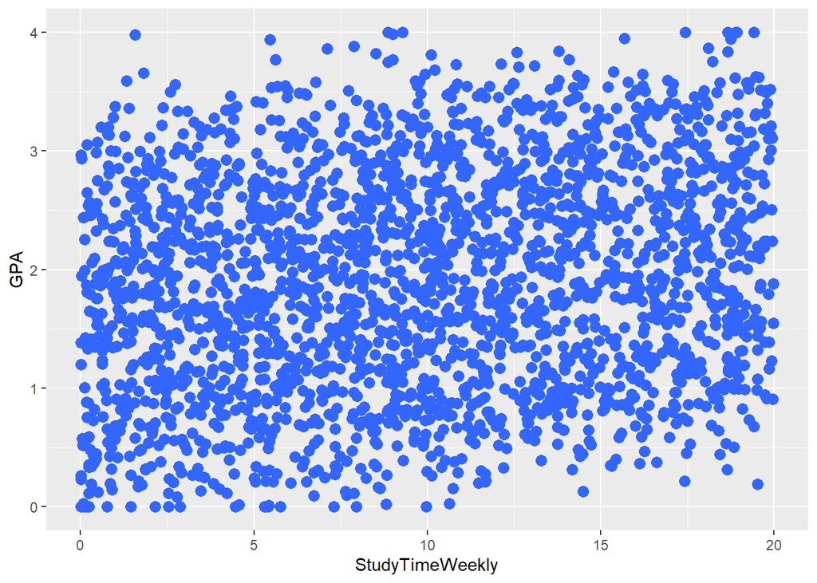

```r
p1 = qplot(StudyTimeWeekly, GPA, data=studentData) + geom_point(colour = "#3366FF", size = 3)
p1
```

```r
cor(studentData$StudyTimeWeekly, studentData$GPA)
```

```
## [1] 0.1792751
```

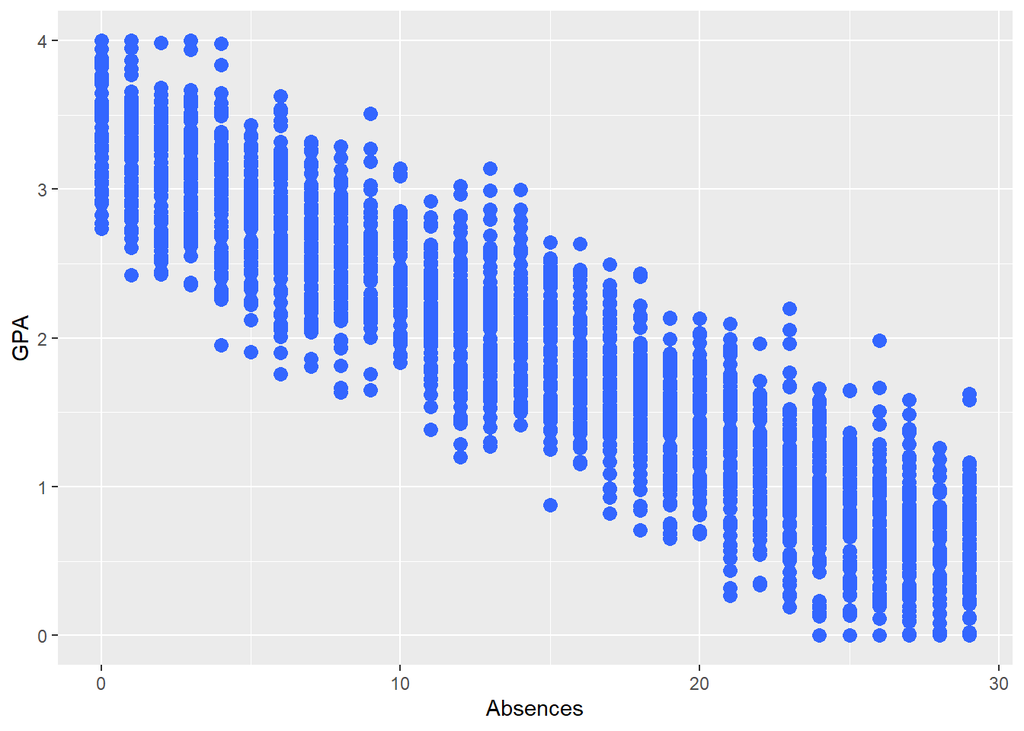

```r
p2 = qplot(Absences, GPA, data=studentData) + geom_point(colour = "#3366FF", size = 3)
p2
```

```r
cor(studentData$Absences, studentData$GPA)
```

```
## [1] -0.9193136
```

### Split the data as Training and Test sets

[output not shown]

### Predict using many variables

Observed close match between predicted and reference values.

```r
lr1 = lm(GPA ~ Absences+StudyTimeWeekly+Tutoring+ParentalSupport+ParentalEducation+Age+Gender+Ethnicity, data=trainStudents)
summary(lr1)
```

```
##
## Call:
## lm(formula = GPA ~ Absences + StudyTimeWeekly + Tutoring + ParentalSupport +
##     ParentalEducation + Age + Gender + Ethnicity, data = trainStudents)
##
## Residuals:
##      Min       1Q   Median       3Q      Max
## -0.89798 -0.16740 -0.00467  0.16806  0.82827
##
## Coefficients:
##                     Estimate Std. Error  t value Pr(>|t|)
## (Intercept)        2.8994092  0.0826023   35.101   <2e-16 ***
## Absences          -0.0994820  0.0006488 -153.323   <2e-16 ***
## StudyTimeWeekly    0.0285756  0.0009698   29.465   <2e-16 ***
## Tutoring           0.2500673  0.0118999   21.014   <2e-16 ***
## ParentalSupport    0.1500227  0.0048614   30.860   <2e-16 ***
## ParentalEducation  0.0032406  0.0054890    0.590   0.5550
## Age               -0.0141757  0.0048634   -2.915   0.0036 **
## Gender             0.0187099  0.0109691    1.706   0.0882 .
## Ethnicity         -0.0026665  0.0053102   -0.502   0.6156
## ---
## Signif. codes:  0 '***' 0.001 '**' 0.01 '*' 0.05 '.' 0.1 ' ' 1
##
## Residual standard error: 0.2395 on 1907 degrees of freedom
## Multiple R-squared:  0.932,  Adjusted R-squared:  0.9317
## F-statistic:  3265 on 8 and 1907 DF,  p-value: < 2.2e-16
```

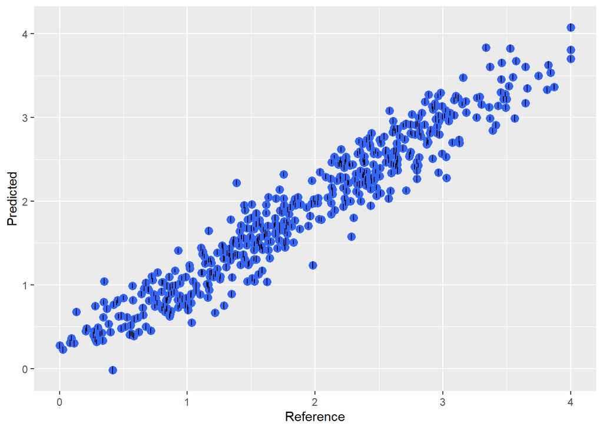

```r
# predict(lr1, testStudents, level=.95, interval="confidence")
predGPA = data.frame(predict(lr1, testStudents, level=.95, interval="confidence"))
names(predGPA)[1] = 'Predicted'
predGPA$Reference = testStudents[,c('GPA')]
qplot(Reference, Predicted, data=predGPA) + geom_point(colour = "#3366FF", size = 3) + geom_errorbar(aes(ymin = lwr,ymax = upr))
```

### Visualizing using `visreg` package

Observed some variables not impacting GPA.

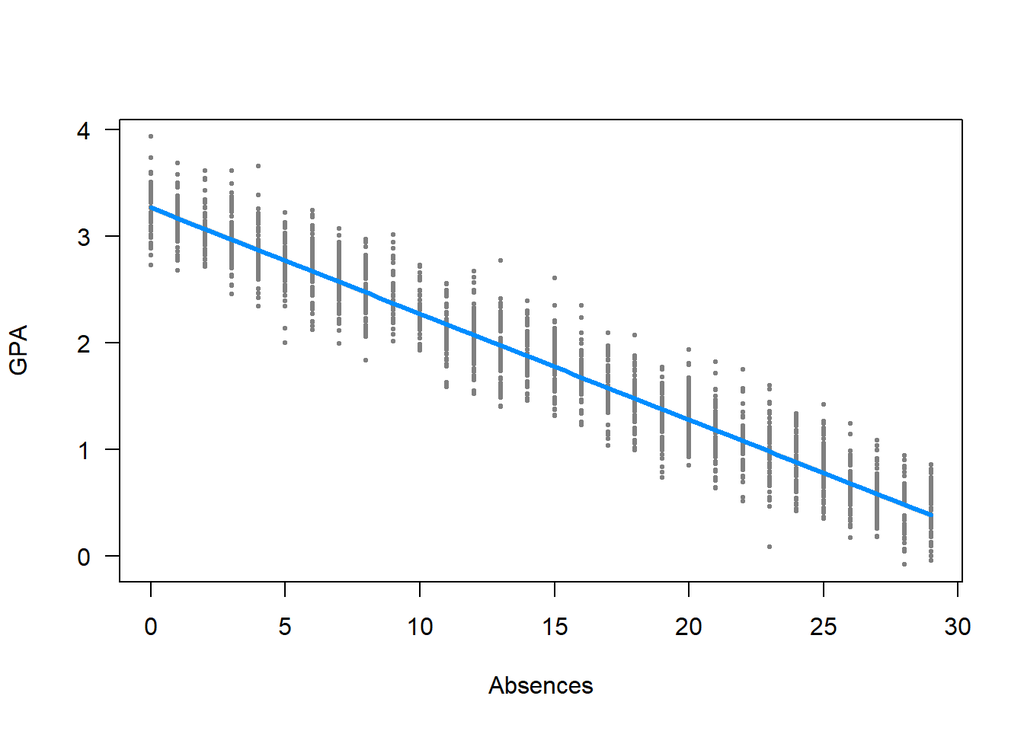

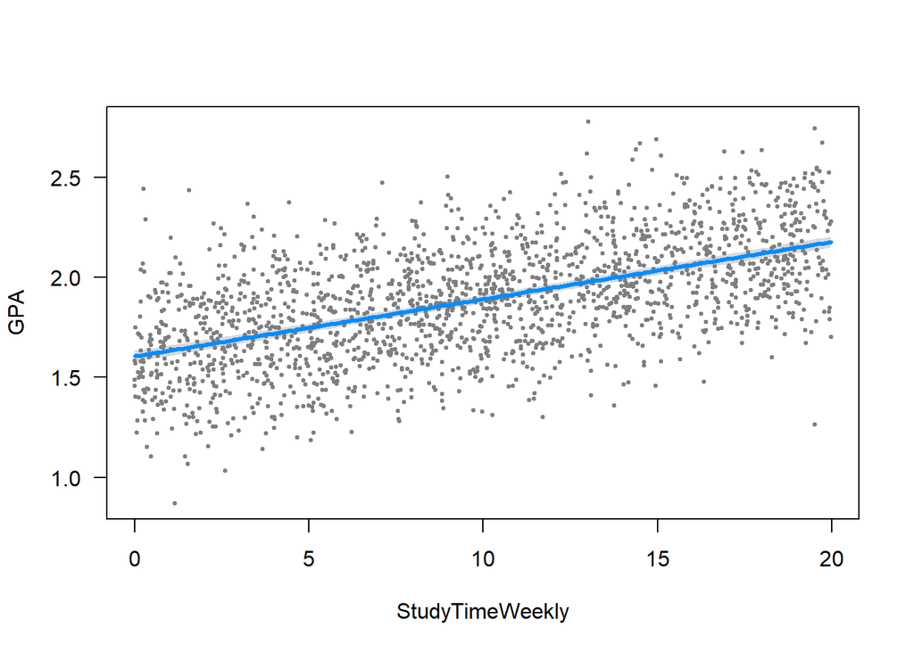

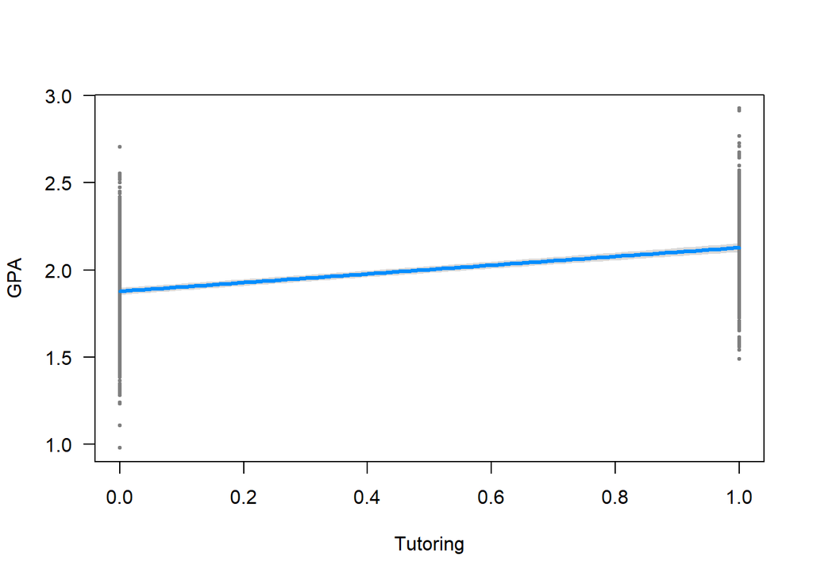

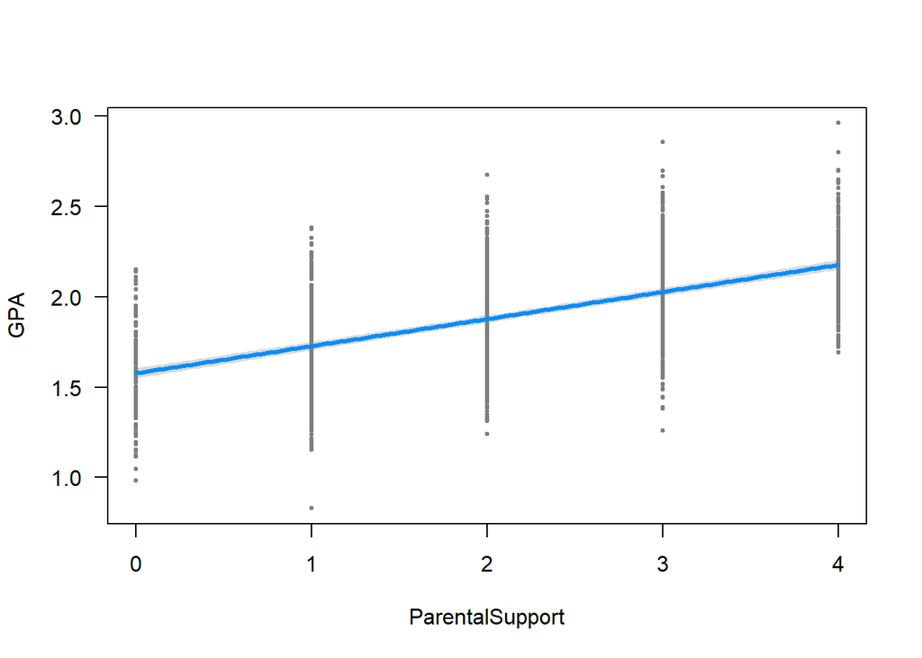

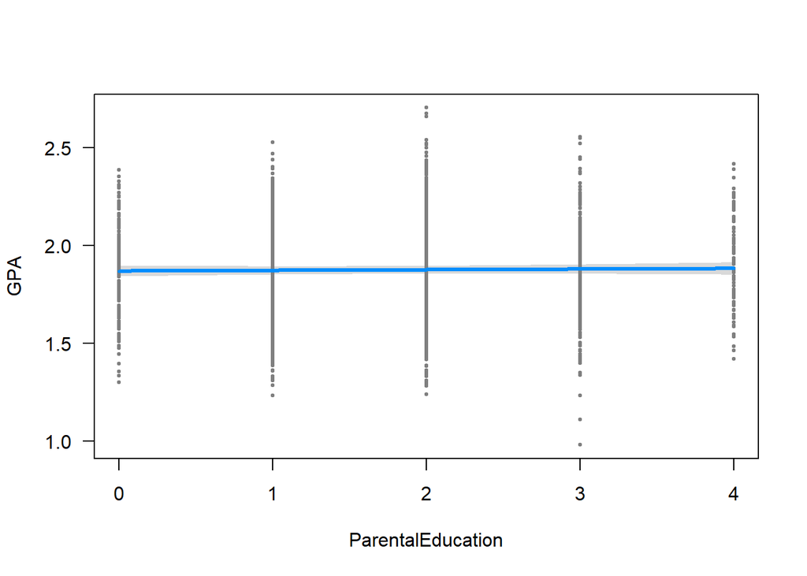

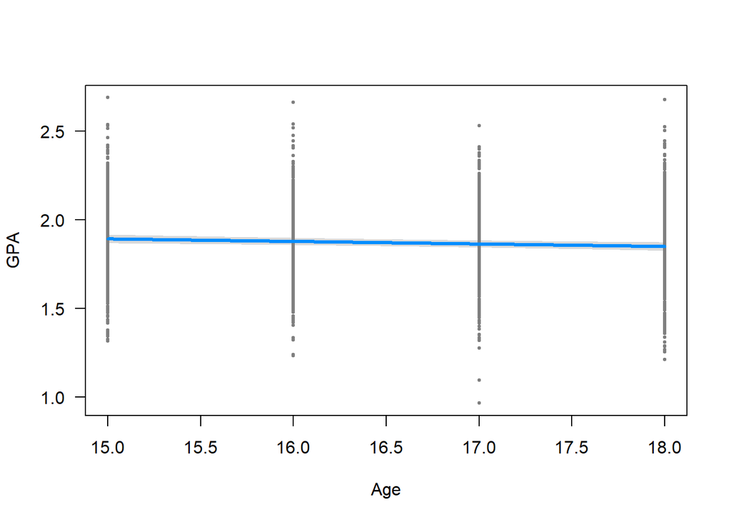

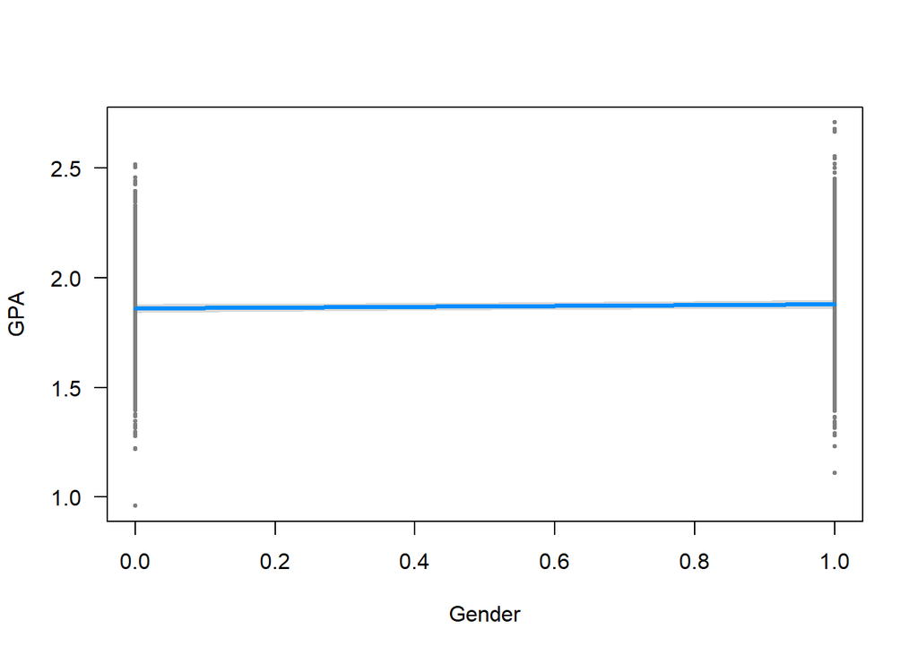

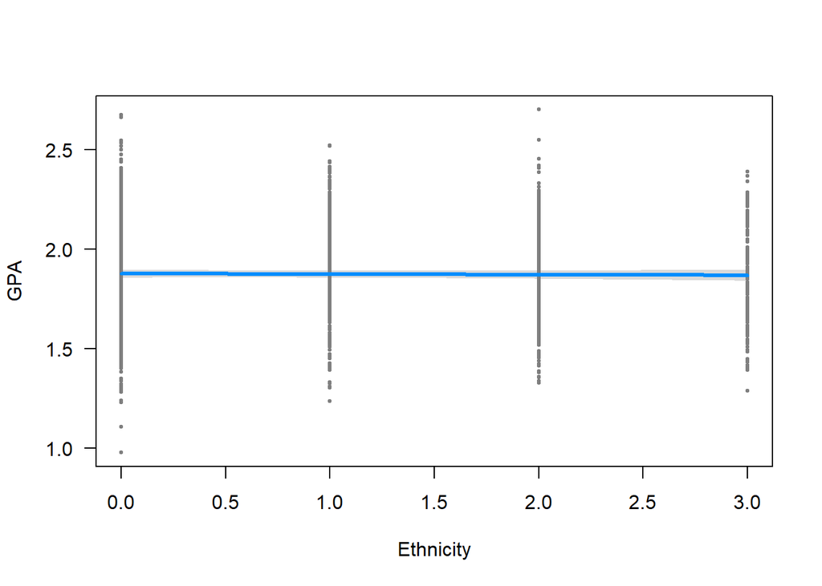

```r
visreg::visreg(lr1)
```

### Predict using just the relevant variables (removed variables not adding value based on above)

```r
lr1 = lm(GPA ~ Absences+StudyTimeWeekly+Tutoring+ParentalSupport+Age, data=trainStudents)
summary(lr1)
```

```
##
## Call:
## lm(formula = GPA ~ Absences + StudyTimeWeekly + Tutoring + ParentalSupport +
##     Age, data = trainStudents)
##
## Residuals:
##      Min       1Q   Median       3Q      Max
## -0.90221 -0.16710 -0.00651  0.16588  0.83448
##
## Coefficients:
##                   Estimate Std. Error  t value Pr(>|t|)
## (Intercept)      2.9038799  0.0818268   35.488  < 2e-16 ***
## Absences        -0.0994176  0.0006471 -153.640  < 2e-16 ***
## StudyTimeWeekly  0.0285957  0.0009698   29.486  < 2e-16 ***
## Tutoring         0.2498245  0.0118958   21.001  < 2e-16 ***
## ParentalSupport  0.1501073  0.0048604   30.884  < 2e-16 ***
## Age             -0.0137335  0.0048564   -2.828  0.00473 **
## ---
## Signif. codes:  0 '***' 0.001 '**' 0.01 '*' 0.05 '.' 0.1 ' ' 1
##
## Residual standard error: 0.2395 on 1910 degrees of freedom
## Multiple R-squared:  0.9318, Adjusted R-squared:  0.9316
## F-statistic:  5221 on 5 and 1910 DF,  p-value: < 2.2e-16
```

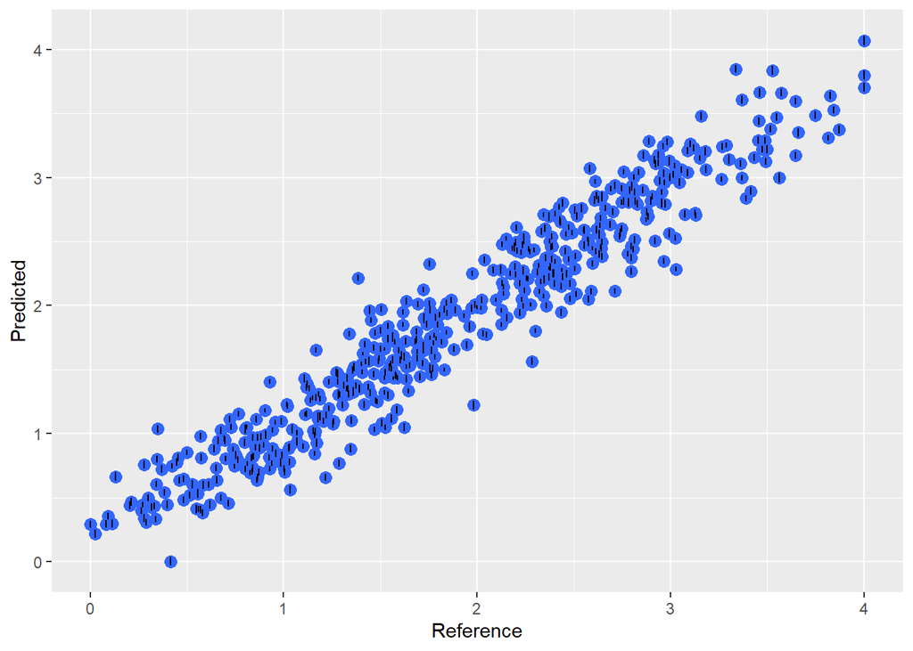

```r
# predict(lr1, testStudents, level=.95, interval="confidence")
predGPA = data.frame(predict(lr1, testStudents, level=.95, interval="confidence"))
names(predGPA)[1] = 'Predicted'
predGPA$Reference = testStudents[,c('GPA')]
qplot(Reference, Predicted, data=predGPA) + geom_point(colour = "#3366FF", size = 3) + geom_errorbar(aes(ymin = lwr,ymax = upr))
```

```r
new_data <- data.frame(
        Age = 17,
        Absences = 10,
        Tutoring = 1,
        ParentalSupport = 1,
        StudyTimeWeekly = 20
      )

 pred <- predict(lr1, new_data)
 pred
```

```
##       1
## 2.64808
```

### Model evaluation with $RMSEP$ and $R^{2}$

- Calculating predicted residual sum of squares (PRESS)
  $$PRESS = \sum_{i=1}^{n}
  (y^{ref}_{i}-y^{pred}_{i})^{2}$$

```r
PRESS = sum((predGPA$Reference - predGPA$Predicted)^2)
PRESS
```

```
## [1] 28.48281
```

- Root mean sqaured error of prediction (RMSEP)
  $$RMSEP = \sqrt{\frac{1}{n_{T}}\sum_{1}^{n_{T}}
  (y_{i}^{ref} - y_{i}^{pred})^{2}}$$

```r
RMSEP = sqrt(PRESS/ nrow(predGPA))
RMSEP
```

```
## [1] 0.2446177
```

- Total sum of squares (SST)
  $$SST =
  \sum_{i=1}^{n} (y^{ref}_{i}-y^{mean}_{i})^{2}$$

```r
SST = sum((predGPA$Reference - mean(predGPA$Reference))^2)
SST
```

```
## [1] 394.8523
```

- Calculating $R^{2}$
  $$R^{2} = 1 - \frac{PRESS}{SST}$$

```r
R2 = 1 - (PRESS/SST)
R2
```

```
## [1] 0.9278646
```

### Result: coefficient of determination (R2) value of .93 and root mean squared error of prediction (RMSEP) of .24 indicates a good linear regression model for GPA prediction.